# Fashion Observation Story

## Introduction

This visual data story explores patterns in fashion observations collected over multiple days. The data was gathered through observational logging using a Google Form created for Project 2 and expanded for Project 4.

The observations focused on clothing styles, top types, estimated ages, and colour categories. By visualising the data, trends in fashion choices and outfit patterns can be identified more clearly.

## Most Common Types of Tops

The first visualisation shows the most commonly observed types of tops across all observations.

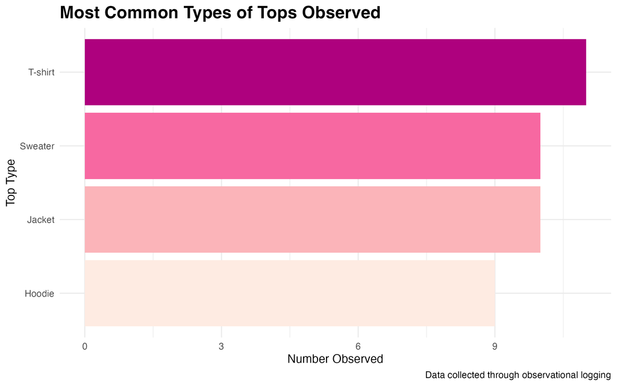

Bar chart showing the number of times each top type was observed. T-shirts were the most frequently observed clothing item, followed by sweaters, jackets, and hoodies.

## Observations Recorded Across Days

The second visualisation focuses on the number of fashion observations recorded on different days. The timestamp data collected through the Google Form was converted into date-time values using functions from the {lubridate} package. This allowed the observations to be grouped by weekday and compared visually.

A column chart was used because it is effective for comparing count-based values across categories. Although the observations were collected over a short period of time, the chart still demonstrates how date-time data can be incorporated into a visual data story.

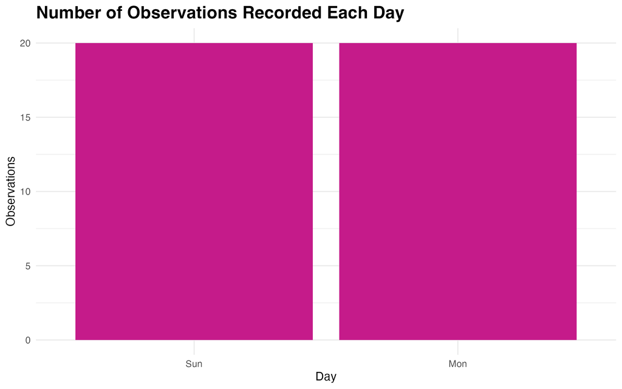

Column chart comparing the number of observations recorded on each day.

## Average Estimated Age by Top Type

The final visualisation compares the average estimated age associated with each observed top type. The data was grouped by top category and summarised using mean estimated age values.

This visualisation helps identify whether certain clothing styles appeared more commonly among different age groups. A horizontal bar chart was chosen because it makes comparisons between categories easier to interpret visually. The blue gradient colour palette was also used to match the overall visual theme of the story.

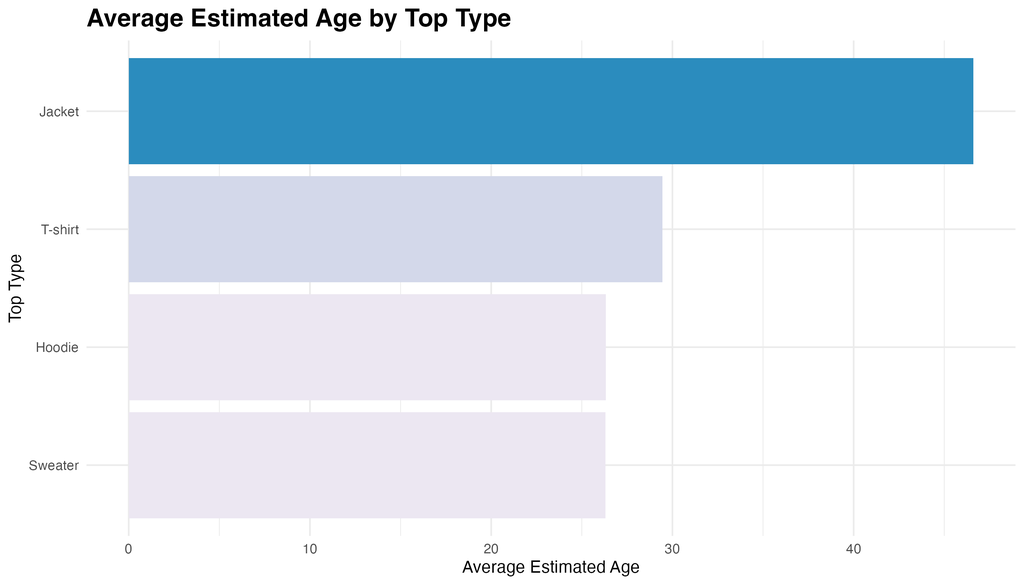

Horizontal bar chart comparing the average estimated age for each top type.